# Module 2 Project: Writing Samplers

# Directions

These 5 sections follow the 5 substantive parts of Module 2 - Generation. Complete each section, including the appropriate output. This document will be used on the exam. For any question make sure to display any requested output. If you use any AI assistance in implementing the R code, be prepared to explain how the implementation works.

Helpful hint: remember to knit the document periodically to make sure the project can be knit prior to printing out your paper copy before the exam.

# Part A: Inversion

## A.1

The generator
$$x_{k+1} = 65539\, x_k
\bmod 2^{31}, \qquad u_k = x_k / 2^{31},$$
is called RANDU.

Write `randu(seed, n)`, which returns $x_1, \ldots, x_n$ starting from $x_0 = {}$`seed`. The mod operator in R is `%%`.

1. Print $x_1, \ldots, x_{10}$ for seed 406. What do all ten have in common?
2. Make a QQ plot of $u_1, \ldots, u_{30000}$ against $U(0, 1)$.
3. The function below groups draws into consecutive triples $(u_1, u_2, u_3), (u_4, u_5, u_6), \ldots$ and plots them as points in the unit cube. Run it on your 30,000 RANDU draws and on 30,000 draws from `runif`. How do the two plots differ?

```r
plot_triples <- function(u) {
  m <- matrix(u, ncol = 3, byrow = TRUE)
  colnames(m) <- c("x", "y", "z")
  lattice::cloud(z ~ x + y, data = as.data.frame(m), pch = 20, cex = 0.1)
}
```

## A.2

`airquality$Wind` holds 153 daily average wind speeds (mph) at LaGuardia Airport, May to September 1973. We model wind speed with the **log-logistic** distribution, which has scale $\alpha > 0$, shape $\beta > 0$ and CDF
$$F(x) = \frac{1}{1 + (x / \alpha)^{-\beta}},
\qquad x > 0.$$
R has no functions for this distribution.

1. Find the quantile function $Q(u)$, and write `rllogis(n, alpha, beta)`. Check 10,000 draws with $\alpha = 10$ and $\beta = 5$ with a QQ plot against your $Q$, as in video 1. `geom_qq` passes extra parameters to the quantile function through `dparams`, for example `geom_qq(distribution = qllogis, dparams = list(alpha = 10, beta = 5))`.
2. The method of moments (module 1) estimates parameters by setting the model’s moments equal to the sample’s and solving. **Quantile matching** does the same with quantiles. With $\hat q_p$ the sample $p$ quantile (`quantile(x, p)`), solve
   $$Q(1/2) = \hat q_{0.5}, \qquad Q(3/4)
   = \hat q_{0.75}$$
   for $\alpha$ and $\beta$. This gives the estimators $\hat\alpha$ and $\hat\beta$. Hint: start with $Q(1/2)$, then divide the second equation by the first. Compute them for the wind data. Then compare the fitted model’s probability of a day above 15 mph with the fraction of days above 15 mph in the data.
3. Simulate 1,000 samples of size 153 from the fitted model. Estimate the bias and MSE of $\hat\beta$, each with a 99% confidence interval.

## A.3

`discoveries` counts the great inventions and scientific discoveries in each year from 1860 to 1959.

```r
d <- as.numeric(discoveries)
table(d)
```

```
## d
##  0  1  2  3  4  5  6  7  8  9 10 12
##  9 12 26 20 12  7  6  4  1  1  1  1
```

1. The Poisson($\lambda$) PMF is
   $$p(x) = \frac{\lambda^x e^{-\lambda}}{x!},
   \qquad x = 0, 1, 2, \ldots,$$
   which `dpois(x, lambda)` computes. Write `rpois_inv(n, lambda)`, which draws Poisson($\lambda$) values by inversion: tabulate the CDF $F(x) = \sum_{i=0}^{x} p(i)$, then for each $u$ find the smallest $x$ with $F(x) \ge u$. Do not use `rpois` or `qpois`. Check 10,000 draws with $\lambda = 3.1$ against `dpois(0:10, 3.1)`.
2. A Poisson variable has variance equal to its mean, so for Poisson counts $S^2 / \bar X$ should be near 1. Compute it for `discoveries`. Simulate its null distribution from 5,000 samples of size 100 drawn with `rpois_inv` at $\lambda = \bar X$, and report the Monte Carlo $p$-value for the alternative that the variance exceeds the mean.

# Part B: Transformations and mixtures

## B.1

Let $X$ and $Y$ be independent $N(0, 1)$, and write the point $(X, Y)$ in polar coordinates: radius $R = \sqrt{X^2 + Y^2}$ and angle $A$, so that $X = R \cos A$ and $Y = R \sin A$.

1. Show that $R^2$ is exponential with rate $1/2$. You may use that $\chi^2(2)$ is the exponential distribution with mean 2.
2. Take as given that $A \sim U(0, 2\pi)$, independent of $R$. Use the exponential quantile function from video 1 to show that for independent $U_1, U_2 \sim U(0, 1)$,
   $$\sqrt{-2 \log U_1} \, \cos(2 \pi U_2) \sim
   N(0, 1).$$
3. Implement this as `rnorm_bm(n)`. Check 10,000 draws with a QQ plot, and estimate $P(X > 2)$ with a 95% confidence interval. Compare with `pnorm(-2)`.

## B.2

A **zero-inflated Poisson** (ZIP) is zero with some extra probability and otherwise Poisson. With a latent $W \sim \text{Bernoulli}(\theta)$ independent of $X \sim \text{Poisson}(\lambda)$, let $Y = WX$.

1. Write `rzip(n, theta, lambda)` from this representation. Use `rpois` for $X$.
2. The method of moments estimators are
   $$\hat \lambda = \frac{S^2 + \bar Y^2}{\bar Y} - 1,
   \qquad
   \hat \theta = 1 - \frac{S^2 - \bar Y}{S^2 + \bar Y^2 - \bar
   Y}.$$
   Fit the ZIP to `discoveries`. How many of the 100 years does the fitted model expect to have no discoveries, and how many did?
3. Simulate 2,000 samples of size 100 from the fitted ZIP, and give a Monte Carlo $p$-value for the observed number of zeros. The alternative is that there are fewer zeros than the model predicts.

# Part C: Accept-reject and importance resampling

The standard Laplace density is $g(x) = \frac{1}{2} e^{-|x|}$. Video 3 samples it by inversion:

```r
rlaplace <- function(n) {
  u <- runif(n)
  ifelse(u < 1/2, log(2 * u), -log(2 - 2 * u))
}
```

## C.1

1. Find with pen and paper the smallest $c$ such that $c \, g(x) \ge \phi(x)$ for all $x$, where $\phi$ is the standard normal density. Treat $x \ge 0$ and $x < 0$ separately.
2. Use accept-reject with 10,000 Laplace candidates to draw standard normals. Check the accepted draws with a QQ plot. Report the acceptance rate with a 95% confidence interval, and compare it with $1/c$.

## C.2

Let $f(x) \propto f^*(x) = \sin(\pi x^2)$ on $0 < x < 1$. Neither method below needs the normalizing constant.

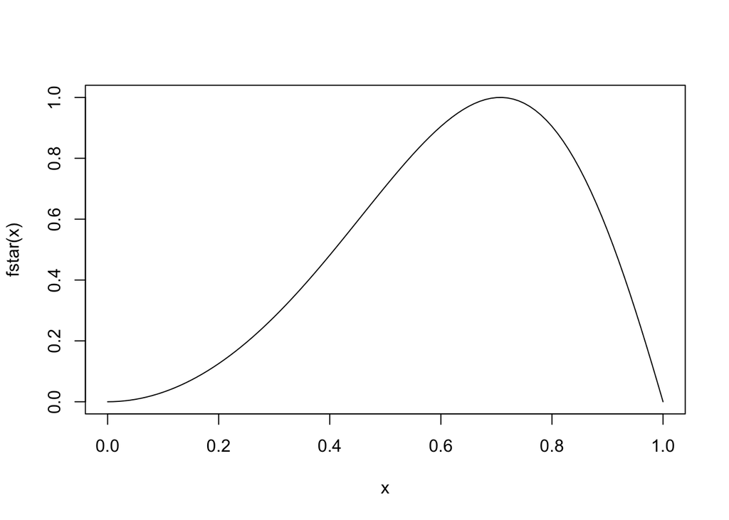

```r
fstar <- function(x) sin(pi * x^2)
curve(fstar(x), from = 0, to = 1)
```

1. Use accept-reject with a $U(0, 1)$ envelope and 10,000 candidates. Since $f^* \le 1$, accept a candidate $Y$ when $U \le f^*(Y)$.
2. Use importance resampling. Draw 10,000 new $U(0, 1)$ candidates, normalize the weights $f^*(Y_i)$, and resample 5,000 draws with `sample(..., replace = TRUE, prob = ...)`.
3. Estimate $\text{E}\left(X\right)$ from each sample, and check both against the exact value from `integrate`.

# Part D: Multivariate distributions and processes

## D.1

`faithful` records 272 eruptions of the Old Faithful geyser: the eruption length and the waiting time to the next eruption, both in minutes.

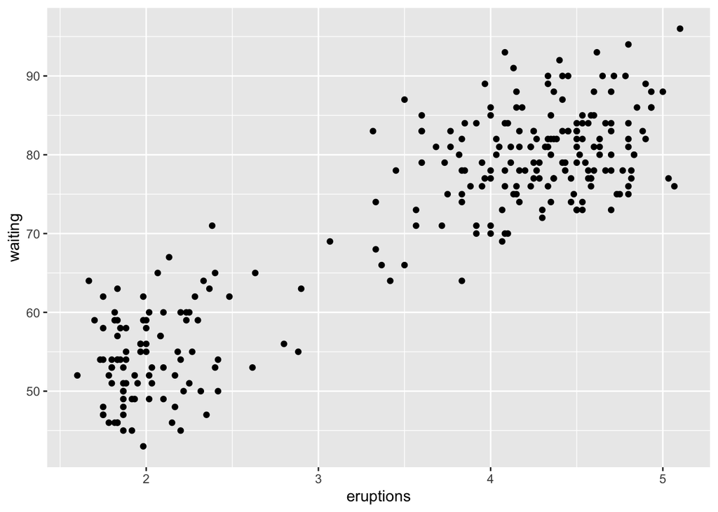

```r
ggplot(faithful, aes(x = eruptions, y = waiting)) + geom_point()
```

We model the pair as a mixture of two bivariate normals: with probability $p$ a draw from $N_2(\mu_1, \Sigma_1)$, and otherwise a draw from $N_2(\mu_2, \Sigma_2)$.

1. Split the eruptions at 3 minutes. Estimate $p$ as the fraction of short eruptions, and each component’s mean and covariance from its group (`colMeans`, `cov`).
2. Write `rfaithful(n)`, which draws from the fitted mixture. Generate each normal component as $\mu + C^T Z$ with `C <- chol(Sigma)`, not with a package function. Plot 272 simulated points next to the data.

## D.2

1. Show that the mean of the mixture is $p \mu_1 + (1 - p) \mu_2$.
2. Compare three covariance matrices: `cov(faithful)`, the covariance of 10,000 draws from `rfaithful`, and $p \Sigma_1 + (1 - p) \Sigma_2$. Is the covariance of a mixture the weighted average of the component covariances?

## D.3

`data/spy.rda` holds the daily closing price of SPY, a fund that tracks the S&P 500, for 3,488 trading days from 2007 to 2020. Prices are adjusted for dividends and splits.

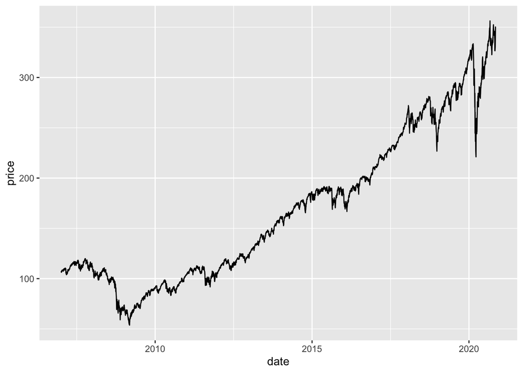

```r
load("../../data/spy.rda")
logp <- log(spy$price)
r <- diff(logp)
ggplot(spy, aes(x = date, y = price)) + geom_line()
```

A simple model for the log price $L_t$ is a Gaussian random walk, $L_t = L_{t-1} + \mu + \sigma Z_t$ with independent $Z_t \sim N(0, 1)$. Under this model the daily log returns $r_t = L_t - L_{t-1}$ are independent $N(\mu, \sigma^2)$.

1. Estimate $\mu$ and $\sigma$ from the returns. Write `rwalk()`, which simulates a log price path of the same length as the data from the fitted walk, starting at the first observed $L_t$. Plot 20 simulated paths with the observed one.
2. The **largest drawdown** is the biggest fall from an earlier peak, $\min_t \left(L_t - \max_{s \le t} L_s\right)$. `cummax` computes the running peak. Compute the largest drawdown for the data, and give a Monte Carlo $p$-value from 1,000 simulated paths. The alternative is that real drawdowns are larger (more negative) than the model’s.
3. Repeat (b) with the correlation between $|r_t|$ and $|r_{t-1}|$ as the statistic. It is large when big moves follow big moves. The alternative is that it is larger than under the model.
4. Which feature of the data does the random walk reproduce, and which does it miss?

# Part E: Gibbs sampling

A Morning Consult/Politico poll asked voters whether Congress should raise the federal minimum wage. Leaving out those with no opinion:

```r
x1 <- 806  # raise it to $15/hr
x2 <- 435  # do not raise it
x3 <- 586  # raise it to $11/hr
```

We model the counts as multinomial with probabilities $\theta_1, \theta_2$ and $\theta_3 = 1 - \theta_1 - \theta_2$:
$$f(x_1, x_2, x_3 \mid \theta_1, \theta_2) \propto
\theta_1^{x_1} \theta_2^{x_2} (1 - \theta_1 -
\theta_2)^{x_3}.$$
The prior is Dirichlet($\delta_1, \delta_2, \delta_3$), which generalizes the Beta to three probabilities that sum to 1:
$$p(\theta_1, \theta_2) \propto
\theta_1^{\delta_1 - 1} \theta_2^{\delta_2 - 1} (1 - \theta_1 -
\theta_2)^{\delta_3 - 1}.$$

## E.1

1. Show that the posterior is Dirichlet($x_1 + \delta_1, x_2 + \delta_2, x_3 + \delta_3$).
2. Show that the full conditional of $\theta_1$ is a scaled Beta,
   $$\theta_1 \mid \theta_2, x \sim (1 - \theta_2) \,
   \text{Beta}(x_1 + \delta_1, \, x_3 + \delta_3),$$
   and state the matching result for $\theta_2 \mid \theta_1, x$. Hint: if $X = aB$ with $a > 0$, then $f_X(x) = f_B(x/a)/a$ (module 1 project, A.1).

## E.2

Write a Gibbs sampler that alternates the two full conditionals from E.1, with every $\delta_i = 1$. Run 5,000 iterations starting from $\theta_1 = \theta_2 = 1/3$, make a trace plot of $\theta_1$ and $\theta_2$, and discard the first 1,000. Report the posterior mean and a 95% credible interval (the 2.5% and 97.5% quantiles of the draws) for $\theta_1$, $\theta_2$ and $\theta_3$, and estimate $P(\theta_1 / \theta_2 > 2 \mid x)$.

## E.3

If $G_1, G_2, G_3$ are independent with $G_i \sim \text{Gamma}(a_i, 1)$, then $(G_1, G_2, G_3) / (G_1 + G_2 + G_3)$ is Dirichlet($a_1, a_2, a_3$). With two components this is the Beta: $G_1 / (G_1 + G_2) \sim \text{Beta}(a_1, a_2)$.

The same construction gives the marginal posterior of $\theta_1$. Write $\theta_1 = G_1 / (G_1 + H)$ with $H = G_2 + G_3$. A sum of independent gammas with the same rate is gamma, so $H \sim \text{Gamma}(a_2 + a_3, 1)$, independent of $G_1$, and therefore $\theta_1 \mid x \sim \text{Beta}(a_1, a_2 + a_3)$.

Both results involve a Beta, but they are different distributions:

|  | distribution | used by |
| --- | --- | --- |
| full conditional $\theta_1 \mid \theta_2, x$ | $(1 - \theta_2)\,\text{Beta}(a_1, a_3)$ | the Gibbs sampler in E.2 |
| marginal $\theta_1 \mid x$ | $\text{Beta}(a_1, a_2 + a_3)$ | the check below |

The conditional depends on the current value of $\theta_2$, and the marginal does not. The Gibbs sampler needs only the conditionals. We use the marginal here to check the chain.

Draw 4,000 values from the posterior directly with the gamma construction. Make QQ plots of the direct draws of $\theta_1$ and of the Gibbs draws of $\theta_1$ against the Beta($a_1, a_2 + a_3$) quantile function (`qbeta`, with the shape parameters passed through `dparams` as in A.2), and compare the two estimates of $P(\theta_1 / \theta_2 > 2 \mid x)$.